# Análisis de la intención de voto en Buenos Aires y Córdoba para las elecciones generales del año 2015

Trabajo final de la materia Investigación Electoral y de Opinión Pública Aplicada I y II

Bardauil Ariana

2023-07-25

# Introducción

El **objetivo** de este trabajo es analizar la intención de voto de dos encuestas realizadas en Buenos Aires y Córdoba realizada de las Primarias Abiertas Simultaneas y Obligatorias (PASO) del 9 de agosto del 2015 para la materia **Investigación Electoral y de Opinión Pública Aplicada I y II.** El resultado de las PASO fue el siguiente:

```r
read_excel("Consigna y materiales TP1/Materiales de referencia/Resultados PASO2015.xlsx",
    sheet = "Hoja2") |>
  mutate(`Buenos Aires` = paste0(round(`Buenos Aires`*100, 2), "%"),
         `Córdoba` = paste0(round(`Córdoba`*100, 2), "%")) |>
  kable(format = "html", escape = FALSE) |>
  kable_styling(bootstrap_options = "striped", font_size = 14)
```

[output not shown]

El 25 de octubre (Primera vuelta) y el 22 de noviembre (segunda vuelta) de 2015 se sucedieron las **elecciones presidenciales de Argentina**. Los **principales candidatos** fueron **Daniel Scioli** del Frente para la Victoria (FpV), candidato oficialista, y **Mauricio Macri** de Cambiemos, entonces jefe de gobierno de la Ciudad de Buenos Aires.

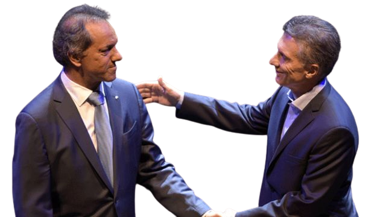

En la primera vuelta electoral, que tuvo lugar el 25 de octubre de 2015, ninguno de los candidatos obtuvo más del 45% de los votos ni una diferencia de más de 10 puntos porcentuales sobre el segundo candidato, lo que llevó a la realización de una segunda vuelta electoral.

- Daniel Scioli (FpV): 37.08% de los votos.
- Mauricio Macri (Cambiemos): 34.15% de los votos.

Daniel Scioli y Mauricio Macri, se enfrentaron en una segunda vuelta electoral el 22 de noviembre de 2015 lo que llevó al segundo a la victoria con el 51.34% de los votos.

## Consigna

Sobre la base de los materiales entregados (Cuestionario y Bases de Resultados de los Estudios Electorales de Córdoba Capital y Base Individuos EPH)

1- Procesar las bases de datos de manera independiente aplicando el método de ponderación iterativa visto en clase (Parámetros en Base EPH).

2- En base a los indicadores relevados evaluar el potencial electoral de los principales candidatos a Presidente (Macri y Scioli)

3- Seleccionar un conjunto de indicadores que den cuenta de al menos dos de las perspectivas teóricas vistas en la bibliografía sobre comportamiento electoral y evaluar el impacto de dichos indicadores en la decisión de voto utilizando al menos dos herramientas de análisis. Comparar los resultados obtenidos entre ambas ciudades.

```r
CORDOBA <- read_sav("Consigna y materiales TP1/Bases de datos/CORDOBA_FINAL.sav")
GBA <- read_sav("Consigna y materiales TP1/Bases de datos/GBA_FINAL.sav")
```

# Análisis Exploratorio

## Resumen de los Datos

En este apartado se realizará la manipulación y transformación de datos como así también el análisis exploratorio de ambas bases

### **Buenos Aires**

En una primera apreciación de la base de **Buenos Aires** se puede observar que existen valores nulos. Estos pueden deberse a respuestas faltantes o preguntas que los encuestados optaron por no responder.

```r
skimr::skim(GBA)
```

Data summary

| Name | GBA |
| --- | --- |
| Number of rows | 373 |
| Number of columns | 20 |
| _______________________ |  |
| Column type frequency: |  |
| character | 7 |
| factor | 12 |
| numeric | 1 |
| ________________________ |  |
| Group variables | None |

**Variable type: character**

| skim_variable | n_missing | complete_rate | min | max | empty | n_unique | whitespace |
| --- | --- | --- | --- | --- | --- | --- | --- |
| voto_candidato | 0 | 1.00 | 7 | 20 | 0 | 8 | 0 |
| voto_acotado | 1 | 1.00 | 7 | 19 | 0 | 5 | 0 |
| jamas_votaria | 2 | 0.99 | 7 | 19 | 0 | 5 | 0 |
| representacion_del_cambio | 0 | 1.00 | 7 | 14 | 0 | 5 | 0 |
| agenda_de_temas | 0 | 1.00 | 6 | 35 | 0 | 6 | 0 |
| percepcion_de_ganador | 0 | 1.00 | 4 | 14 | 0 | 5 | 0 |
| votacion_paso | 0 | 1.00 | 5 | 22 | 0 | 8 | 0 |

**Variable type: factor**

| skim_variable | n_missing | complete_rate | ordered | n_unique | top_counts |
| --- | --- | --- | --- | --- | --- |
| edad | 0 | 1.00 | TRUE | 4 | 50-: 168, 30-: 94, 18-: 60, >65: 51 |
| sexo | 0 | 1.00 | TRUE | 2 | Muj: 196, Var: 177 |
| niv_educativo | 0 | 1.00 | TRUE | 5 | Sec: 139, Pri: 80, Ter: 64, Uni: 61 |
| gestion_cristina | 0 | 1.00 | TRUE | 3 | Des: 192, Apr: 145, No : 36 |
| economia_pais_2_anos | 0 | 1.00 | TRUE | 4 | Emp: 177, Mej: 110, Se : 80, No : 6 |
| economia_fliar_2_anos | 3 | 0.99 | TRUE | 4 | Emp: 134, Se : 124, Mej: 103, No : 9 |
| continuidad_o_cambio | 3 | 0.99 | TRUE | 4 | Man: 199, Man: 88, Cam: 73, No : 10 |
| influencia_de_cristina_en_scioli | 83 | 0.78 | TRUE | 4 | Bas: 149, Poc: 74, Nin: 38, No : 29 |
| posicionamiento_espacial | 0 | 1.00 | TRUE | 6 | Ni : 224, No : 47, Más: 39, Tot: 28 |
| posicionamiento_respecto_peronismo | 0 | 1.00 | TRUE | 4 | Ni : 209, Per: 124, Ant: 23, No : 17 |
| posicionamiento_respecto_kirchnerismo | 0 | 1.00 | TRUE | 4 | Ni : 151, Ant: 110, Kir: 100, No : 12 |
| ne_bsas | 0 | 1.00 | TRUE | 3 | Sec: 203, Ter: 90, P. : 80 |

**Variable type: numeric**

| skim_variable | n_missing | complete_rate | mean | sd | p0 | p25 | p50 | p75 | p100 | hist |
| --- | --- | --- | --- | --- | --- | --- | --- | --- | --- | --- |
| ua | 0 | 1 | 187 | 107.82 | 1 | 94 | 187 | 280 | 373 | ▇▇▇▇▇ |

### **Córdoba**

Al igual que con el df de Buenos Aires, vemos que en el dataframe de **Córdoba** existen valores nulos.

```r
skimr::skim(CORDOBA)
```

Data summary

| Name | CORDOBA |
| --- | --- |
| Number of rows | 320 |
| Number of columns | 20 |
| _______________________ |  |
| Column type frequency: |  |
| character | 7 |
| factor | 12 |
| numeric | 1 |
| ________________________ |  |
| Group variables | None |

**Variable type: character**

| skim_variable | n_missing | complete_rate | min | max | empty | n_unique | whitespace |
| --- | --- | --- | --- | --- | --- | --- | --- |
| voto_candidato | 0 | 1 | 7 | 20 | 0 | 8 | 0 |
| voto_acotado | 0 | 1 | 7 | 19 | 0 | 5 | 0 |
| jamas_votaria | 0 | 1 | 7 | 19 | 0 | 5 | 0 |
| representacion_del_cambio | 0 | 1 | 7 | 14 | 0 | 5 | 0 |
| agenda_de_temas | 1 | 1 | 6 | 35 | 0 | 6 | 0 |
| percepcion_de_ganador | 0 | 1 | 4 | 14 | 0 | 5 | 0 |
| votacion_paso | 0 | 1 | 5 | 22 | 0 | 8 | 0 |

**Variable type: factor**

| skim_variable | n_missing | complete_rate | ordered | n_unique | top_counts |
| --- | --- | --- | --- | --- | --- |
| edad | 0 | 1.00 | TRUE | 4 | 50-: 103, 30-: 96, 18-: 64, >65: 57 |
| sexo | 0 | 1.00 | TRUE | 2 | Muj: 179, Var: 141 |
| niv_educativo | 0 | 1.00 | TRUE | 5 | Uni: 120, Sec: 70, Ter: 58, Ter: 38 |
| gestion_cristina | 0 | 1.00 | TRUE | 3 | Des: 210, Apr: 84, No : 26 |
| economia_pais_2_anos | 3 | 0.99 | TRUE | 4 | Emp: 198, Se : 57, Mej: 48, No : 14 |
| economia_fliar_2_anos | 0 | 1.00 | TRUE | 4 | Emp: 143, Se : 97, Mej: 63, No : 17 |
| continuidad_o_cambio | 0 | 1.00 | TRUE | 4 | Man: 180, Cam: 75, Man: 42, No : 23 |
| influencia_de_cristina_en_scioli | 1 | 1.00 | TRUE | 5 | Muc: 118, Bas: 102, Poc: 47, No : 31 |
| posicionamiento_espacial | 0 | 1.00 | TRUE | 6 | Ni : 202, No : 37, Más: 36, Más: 20 |
| posicionamiento_respecto_peronismo | 0 | 1.00 | TRUE | 4 | Ni : 207, Per: 47, Ant: 34, No : 32 |
| posicionamiento_respecto_kirchnerismo | 0 | 1.00 | TRUE | 4 | Ni : 135, Ant: 124, Kir: 33, No : 28 |
| ne_cba | 0 | 1.00 | TRUE | 3 | Ter: 158, Sec: 128, P. : 34 |

**Variable type: numeric**

| skim_variable | n_missing | complete_rate | mean | sd | p0 | p25 | p50 | p75 | p100 | hist |
| --- | --- | --- | --- | --- | --- | --- | --- | --- | --- | --- |
| ua | 0 | 1 | 160.5 | 92.52 | 1 | 80.75 | 160.5 | 240.25 | 320 | ▇▇▇▇▇ |

### Tratamiento de los valores nulos

Para el tratamiento de los mismos se utilizará el paquete {mice} *Multiple Imputation by Chained Equations*. Este método imputa los datos faltantes a través de una serie iterativa de modelos predictivos

### **Buenos Aires**

En este subpanel se buscará realizar el tratamiento de los valores nulos de la base de **Buenos Aires**

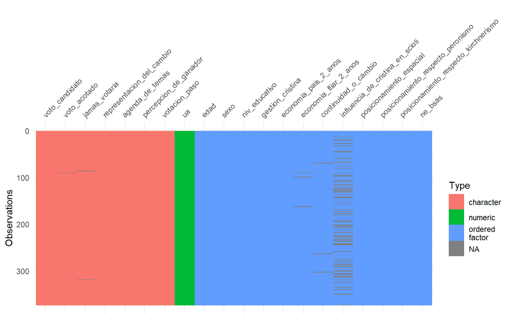

```r
GBA %>% visdat::vis_dat(warn_large_data = F)
```

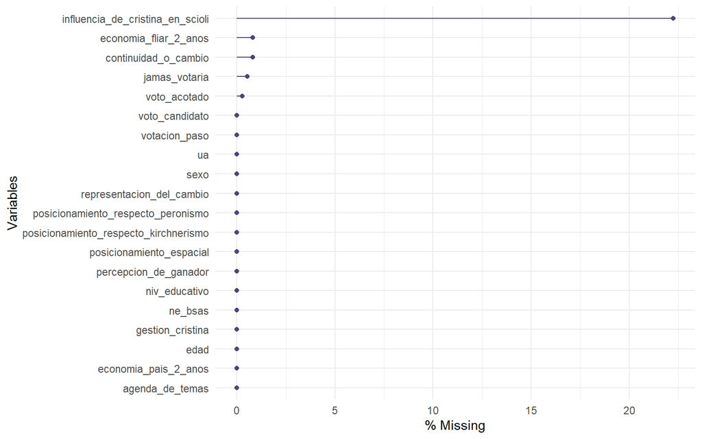

```r
naniar::gg_miss_var(GBA, show_pct = T)
```

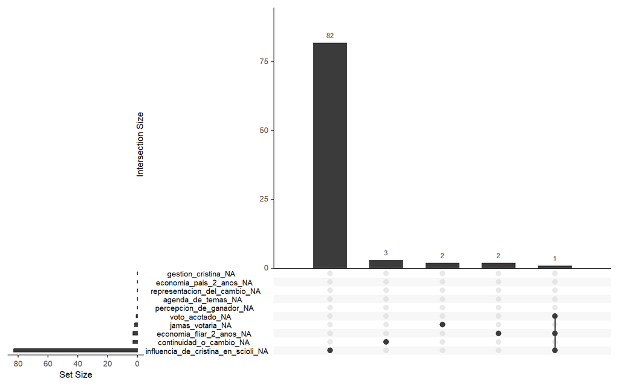

```r
naniar::gg_miss_upset(GBA,nsets = 10)
```

Como se puede ver en los gráficos anteriores, la variable que más posee valores nulos es `influencia_de_cristina_en_scioli`. Esta variable no se encuentra relacionada directamente con otras. Por lo que no se debe a un salto por no completar alguna pregunta de la encuesta.

```r
# Convierto las variables a factor
df_bsas <- GBA  |>
  mutate_all(as.factor) |>
  mutate(ua = as.numeric(ua))

mice_object <- mice(df_bsas, method = "polyreg")
summary(mice_object)
df_gba_sin_NA <- complete(mice_object)
```

Mostramos el resultado de la imputación

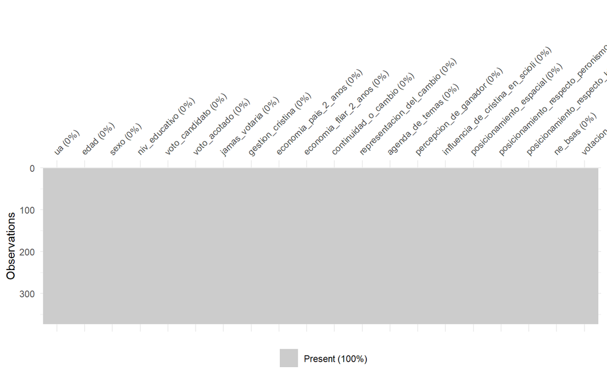

```r
visdat::vis_miss(df_gba_sin_NA)
```

Como se puede ver en el gráfico ya no hay valores nulos. Los mismos fueron imputados satisfactoriamente por `mice` .

### **Córdoba**

En este subpanel se buscará realizar el tratamiento de los valores nulos de la base de **Córdoba**

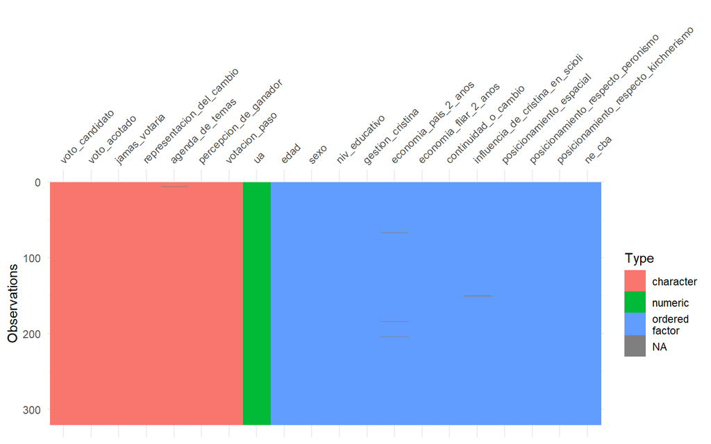

```r
CORDOBA %>% visdat::vis_dat(warn_large_data = F)
```

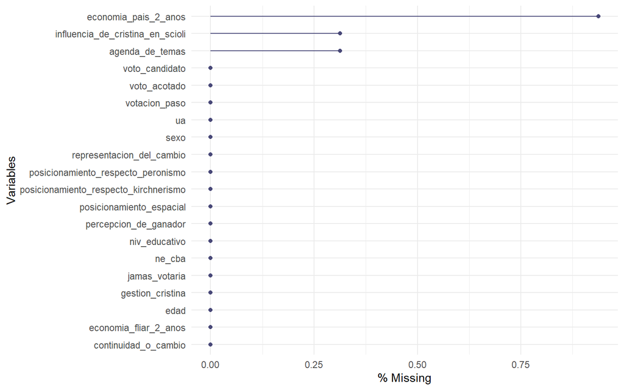

```r
naniar::gg_miss_var(CORDOBA, show_pct = T)
```

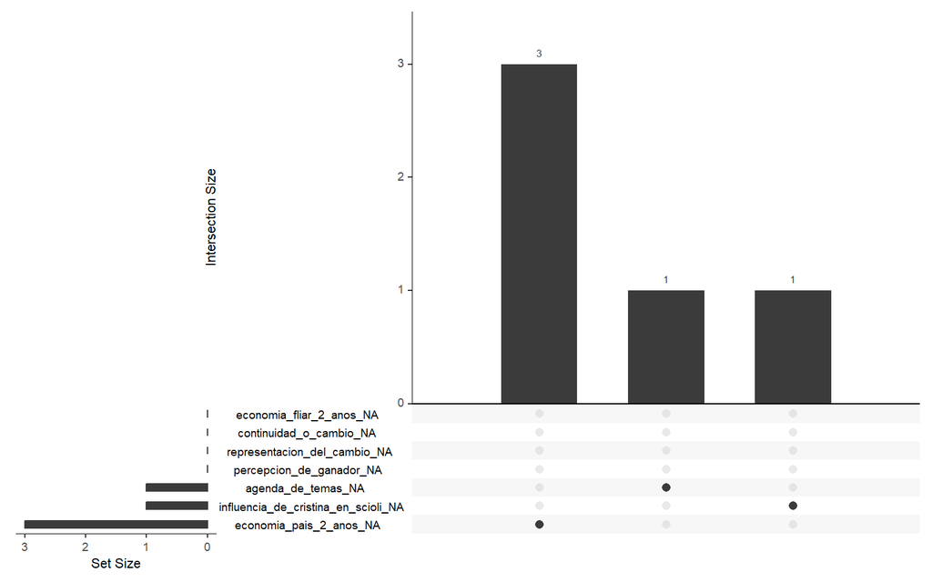

```r
naniar::gg_miss_upset(CORDOBA,nsets = 10)
```

A diferencia del dataset de Buenos Aires, se observa menos cantidad de valores nulos. Se procederá a imputar los mismos:

```r
# Convierto las variables a factor
df_cordoba <- CORDOBA  |>
  mutate_all(as.factor) |>
  mutate(ua = as.numeric(ua))

mice_object <- mice(df_cordoba, method = "polyreg")
summary(mice_object)
df_cordoba_sin_NA <- complete(mice_object)
```

Mostramos el resultado de la imputación:

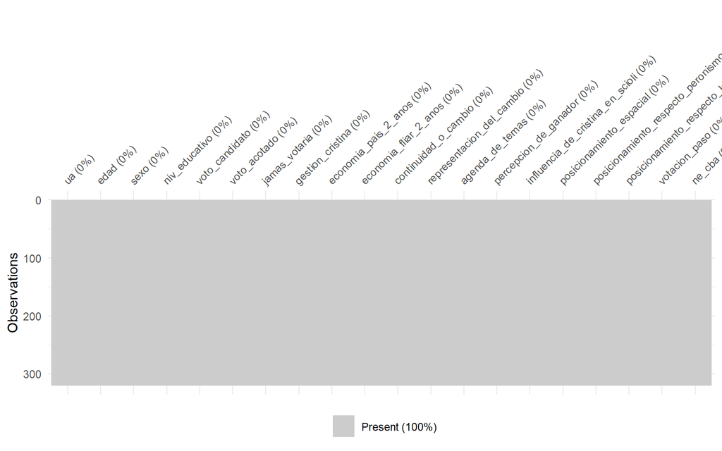

```r
visdat::vis_miss(df_cordoba_sin_NA)
```

## Explorando los datos

### **Buenos Aires**

A continuación se analizará el dataset de **Buenos Aires.**El paquete {Hmisc} permite una buena visualización de la distribución de las variables categóricas. Algunas observaciones:

```r
# analizamos los datos
resumen_gba <- Hmisc::describe(df_gba_sin_NA, transpose = FALSE,tabular = FALSE)


resumen_gba
```

```
## df_gba_sin_NA
##
##  20  Variables      373  Observations
## --------------------------------------------------------------------------------
## ua
##        n  missing distinct     Info     Mean      Gmd      .05      .10
##      373        0      373        1      187    124.7     19.6     38.2
##      .25      .50      .75      .90      .95
##     94.0    187.0    280.0    335.8    354.4
##
## lowest :   1   2   3   4   5, highest: 369 370 371 372 373
## --------------------------------------------------------------------------------
## edad
##        n  missing distinct
##      373        0        4
##
## Value      18-29 30-49 50-65   >65
## Frequency     60    94   168    51
## Proportion 0.161 0.252 0.450 0.137
## --------------------------------------------------------------------------------
## sexo
##        n  missing distinct
##      373        0        2
##
## Value      Varón Mujer
## Frequency    177   196
## Proportion 0.475 0.525
## --------------------------------------------------------------------------------
## niv_educativo
##        n  missing distinct
##      373        0        5
##
## Primario completo (80, 0.214), Secundario incompleto o completo (139, 0.373),
## Terciario no univ. incompleto (64, 0.172), Terciario no univ. completo (29,
## 0.078), Universitario incompleto o completo (61, 0.164)
## --------------------------------------------------------------------------------
## voto_candidato
##        n  missing distinct
##      373        0        8
##
```

[output cut: 132 more lines]

```
##        n  missing distinct
##      373        0        3
##
## Value              P. Completa Sec. Comp-Terc. Inc Terc/Univ. Completo
## Frequency                   80                 203                  90
## Proportion               0.214               0.544               0.241
## --------------------------------------------------------------------------------
## votacion_paso
##        n  missing distinct
##      373        0        8
##
## Blanco / No voto (23, 0.062), Daniel Scioli (133, 0.357), José Manuel De La
## Sota (5, 0.013), Margarita Stolbizer (25, 0.067), Mauricio Macri (79, 0.212),
## Otros (33, 0.088), Rodriguez Saa (7, 0.019), Sergio Massa (68, 0.182)
## --------------------------------------------------------------------------------
```

Sobre el `voto_candidato` el 38.6% tiene intenciones de votar a Daniel Scioli, el 29.8% a Mauricio Macri y, el 21.4% a Sergio Massa. En esta misma linea, se obsevan los resultados de `voto_acotado` . En `jamas_votaria` rankea Daniel Scioli con un 44.2%.

El 51.5% desaprueba la `gestion_cristina`, para el 47.5% la economía en estos ultimos dos años empeoró (`economia_pais_2_anos`), el 36.2% considera que su economía familiar empeoro (`economia_fliar_2_anos`). Sin embargo, para el 53.6% se debería mantener algunas políticas y cambiar otras y el 24% piensa que habría que mantener todas las políticas (`continuidad_o_cambio`). Sobre este punto, el 34% sostiene que la representación del cambio (`representacion_del_cambio`) está en manos de Mauricio Macri y el 31.4 de Daniel Scioli

En relación con el posicionamiento de los encuestados: El 60% no se considera ni de izquierda ni de derecha (`posicionamiento_espacial`) y el 56% no se define ni como peronista ni antiperonista (`posicionamiento_respecto_peronismo`). Lo mismo sucede con el posicionamiento respecto al kirchnerismo, el 40.5% no se considera K ni antiK, el 29% es antiK y el 26.8% es K

Sobre qué votaron en las PASO, el 35.7% votó a Daniel Scioli y el 21.2% a Mauricio Macri

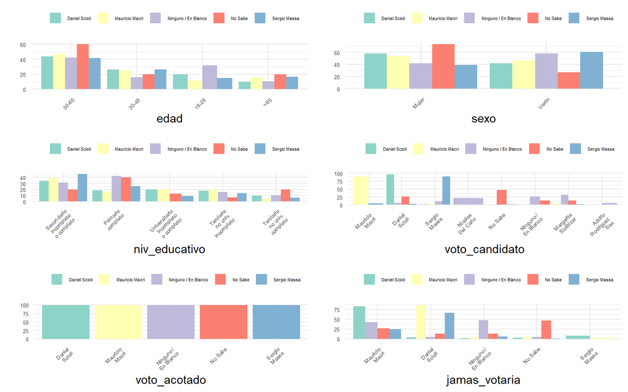

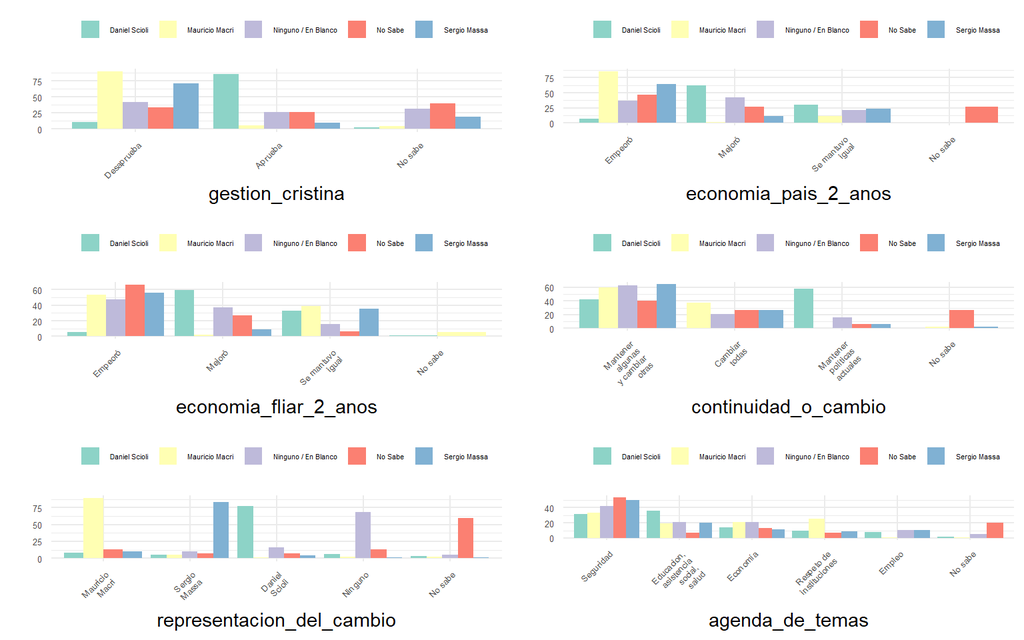

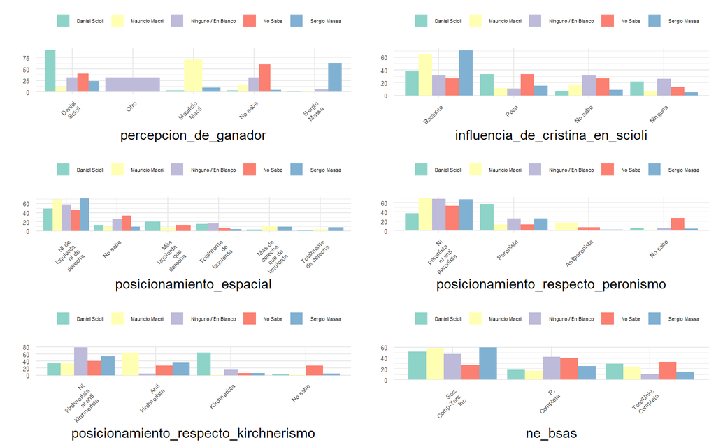

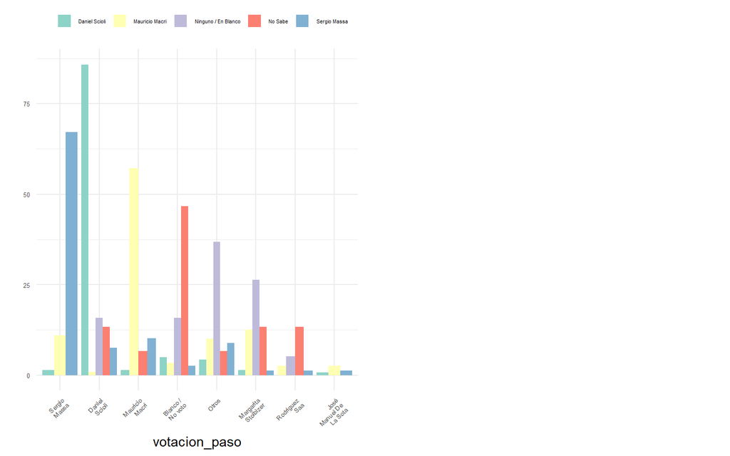

```r
df_categoricas <- df_gba_sin_NA %>%
  select_if(is.factor)

# Creo una lista
lista_graficos <- list()

# Armo un loop para graficar todos
for (col in names(df_categoricas)) {
  # Calculamos la frecuencia de cada
  frecuencias <- df_gba_sin_NA %>%
    count(!!sym(col), voto_acotado ) %>%
    group_by(voto_acotado) %>%
    mutate(porcentaje = n / sum(n) * 100)


  # Graficamos
  grafico_barras_apilados <- ggplot(frecuencias, aes(x = reorder(!!sym(col), -porcentaje), y = porcentaje, fill = as.factor(voto_acotado))) +
    geom_bar(position = 'dodge',stat = "identity") +
    labs(title = NULL, x = col, y = " ", fill = "Voto Acotado") +
    guides(fill = guide_legend(title = " ")) +
    scale_fill_brewer(palette = "Set3") +#
    theme_minimal() +
    theme(axis.text.x = element_text(hjust = 1, size = 5, angle = 45),
          axis.text.x.top = element_text(hjust = 1, size = 5,angle = 45),
          axis.text.y = element_text(size = 5),
          legend.position = 'top',
          legend.text = element_text(size = 4),
          legend.key.size = unit(0.4, 'cm'), # es para los cuadraditos
          legend.key.width = unit(0.4, 'cm')
          ) +
    scale_x_discrete(labels = function(x) str_wrap(x, width = 10))

  # Guardo los gráficos en la lista
  lista_graficos[[col]] <- grafico_barras_apilados
}

# Armamos varias grillas para que no se apelmace
num_grillas <- ceiling(length(lista_graficos) / 6)
grillas <- lapply(1:num_grillas, function(i) {
  inicio <- (i - 1) * 6 + 1
  fin <- min(i * 6, length(lista_graficos))
  grid.arrange(grobs = lista_graficos[inicio:fin], ncol = 2)
})
```

En este gráfico se muestra por variable la distribución del `voto_acotado` . En relación con las **variables sociodemográficas** podemos decir que dentro del rango de edad 50-65 el “No sabe” lidera las respuestas, en segundo lugar Mauricio Macri y tercero Daniel Scioli. Entre los 18-29 años el voto en blanco o ninguno tiene mayor proporcion. Daniel Scioli tiene mayor proporción de Voto Femenino, y Sergio Massa masculino. Y, Sergio Massa lidera entre los que poseen secundario completo o incompleto y universitario y terciario está parejo entre Macri y Scioli

Respecto a las variables económicas: Quienes desaprueban la gestión cristina en mayor medida votarán a Mauricio Macri y, entre quienes la aprueban votarána a Daniel Scioli (`gestion_cristina`). En el mismo sentido, quienes consideran que su situación económica empeoró (`economia_pais_2_anos` y `economia_fliar_2_anos`) votarán a la oposición y, a la inversa, al oficialismo

### **Córdoba**

A continuación se analizará el dataset de **Córdoba.**

```r
resumen_cba <- Hmisc::describe(df_cordoba_sin_NA, transpose = FALSE,tabular = FALSE)

resumen_cba
```

```
## df_cordoba_sin_NA
##
##  20  Variables      320  Observations
## --------------------------------------------------------------------------------
## ua
##        n  missing distinct     Info     Mean      Gmd      .05      .10
##      320        0      320        1    160.5      107    16.95    32.90
##      .25      .50      .75      .90      .95
##    80.75   160.50   240.25   288.10   304.05
##
## lowest :   1   2   3   4   5, highest: 316 317 318 319 320
## --------------------------------------------------------------------------------
## edad
##        n  missing distinct
##      320        0        4
##
## Value      18-29 30-49 50-65   >65
## Frequency     64    96   103    57
## Proportion 0.200 0.300 0.322 0.178
## --------------------------------------------------------------------------------
## sexo
##        n  missing distinct
##      320        0        2
##
## Value      Varón Mujer
## Frequency    141   179
## Proportion 0.441 0.559
## --------------------------------------------------------------------------------
## niv_educativo
##        n  missing distinct
##      320        0        5
##
## Primario completo (34, 0.106), Secundario incompleto o completo (70, 0.219),
## Terciario no univ. incompleto (58, 0.181), Terciario no univ. completo (38,
## 0.119), Universitario incompleto o completo (120, 0.375)
## --------------------------------------------------------------------------------
## voto_candidato
##        n  missing distinct
##      320        0        8
##
```

[output cut: 131 more lines]

```
##        n  missing distinct
##      320        0        8
##
## Blanco / No voto (23, 0.072), Daniel Scioli (53, 0.166), José Manuel De La Sota
## (31, 0.097), Margarita Stolbizer (18, 0.056), Mauricio Macri (104, 0.325),
## Otros (33, 0.103), Rodriguez Saa (25, 0.078), Sergio Massa (33, 0.103)
## --------------------------------------------------------------------------------
## ne_cba
##        n  missing distinct
##      320        0        3
##
## Value              P. Completa Sec. Comp-Terc. Inc Terc/Univ. Completo
## Frequency                   34                 128                 158
## Proportion               0.106               0.400               0.494
## --------------------------------------------------------------------------------
```

En `voto_candidato` el 46.9% votaría a Mauricio Macri y el 23.4% a Daniel Scioli. Esta distribución se mantiene en `voto_acotado` . Además, el 63.4% jamás votaría a Daniel Scioli y el 24.1% a Mauricio Macri.

En relación con la gestión del Gobierno de Cristina (`gestion_cristina`) 65.6% de los cordobeses encuestados la desaprueba y el 62.2% considera que la situación económica del país empeoró en los últimos dos años (`economia_pais_2_anos`). No obstante, si bien el 44% de los encuestados cree que su situación económica familiar empeoró, el 30% considera que no hubo cambio (`economia_fliar_2_anos`)

Para el 37.5 % el ganador será Mauricio Macri y para el 36.6% será Daniel Scioli (`percepcion_de_ganador`). En linea, el 37.2% considera que hay influencia de CFK en Daniel Scioli (`influencia_de_cristina_en_scioli`)

Sobre la posición ideológica de los encuestados:

- El 63.1% no se considera ni de izquierda ni de derecha (`posicionamiento_espacial`)
- El 64.7% no es ni peronista ni antiperonista (`posicionamiento_respecto_peronismo`)
- El 42.2% no es K ni AntiK, pero el 38.8% se considera antikirchnerista (`posicionamiento_respecto_kirchnerismo`)

Por último, en las PASO el 32.5 votó a Mauricio Macri, y el 16.6% a Daniel Scioli (`votacion_paso`)

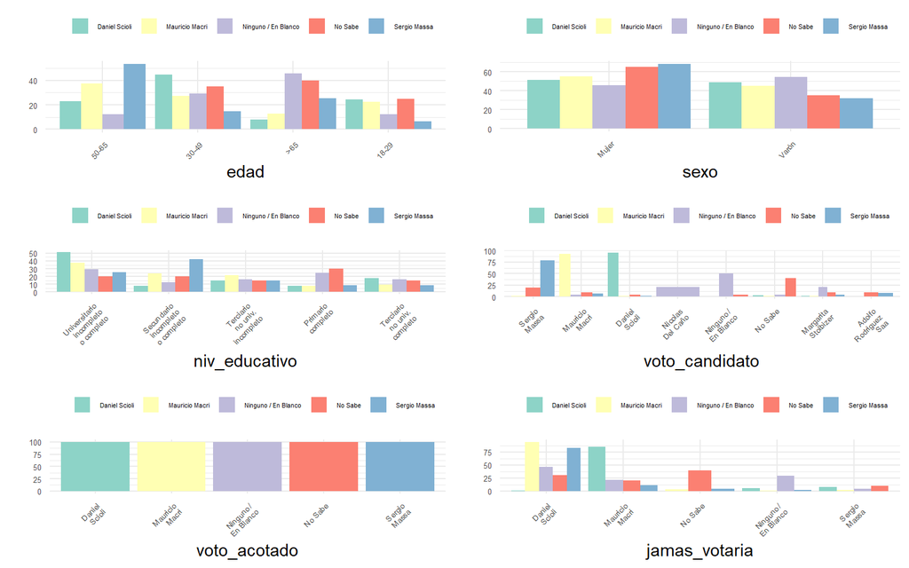

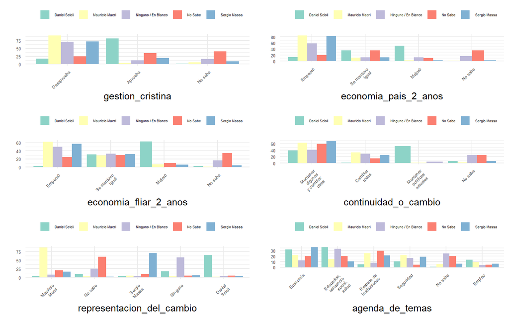

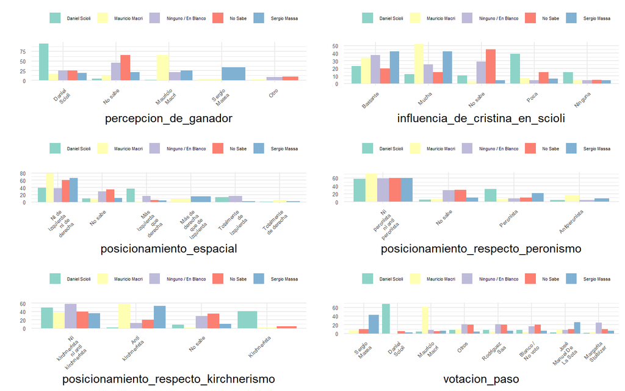

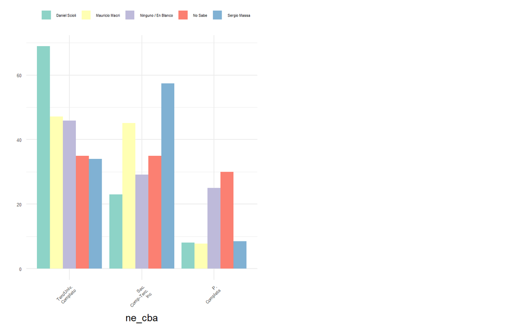

```r
df_categoricas <- df_cordoba_sin_NA %>%
  select_if(is.factor)

# Creo una lista
lista_graficos <- list()

# Armo un loop para graficar todos
for (col in names(df_categoricas)) {
  # Calculamos la frecuencia de cada
  frecuencias <- df_cordoba_sin_NA %>%
    count(!!sym(col), voto_acotado ) %>%
    group_by(voto_acotado) %>%
    mutate(porcentaje = n / sum(n) * 100)


  # Graficamos
  grafico_barras_apilados <- ggplot(frecuencias, aes(x = reorder(!!sym(col), -porcentaje), y = porcentaje, fill = as.factor(voto_acotado))) +
    geom_bar(position = 'dodge',stat = "identity") +
    labs(title = NULL, x = col, y = " ", fill = "Voto Acotato") +
    guides(fill = guide_legend(title = " ")) +
    scale_fill_brewer(palette = "Set3") +#
    theme_minimal() +
    theme(axis.text.x = element_text(hjust = 1, size = 5, angle = 45),
          axis.text.x.top = element_text(hjust = 1, size = 5,angle = 45),
          axis.text.y = element_text(size = 5),
          legend.position = 'top',
          legend.text = element_text(size = 4),
          legend.key.size = unit(0.4, 'cm'), # es para los cuadraditos
          legend.key.width = unit(0.4, 'cm')
          ) +
    scale_x_discrete(labels = function(x) str_wrap(x, width = 10))

  # Guardo los gráficos en la lista
  lista_graficos[[col]] <- grafico_barras_apilados
}

# Armamos varias grillas para que no se apelmace
num_grillas <- ceiling(length(lista_graficos) / 6)
grillas <- lapply(1:num_grillas, function(i) {
  inicio <- (i - 1) * 6 + 1
  fin <- min(i * 6, length(lista_graficos))
  grid.arrange(grobs = lista_graficos[inicio:fin], ncol = 2)
})
```

# Ponderación iterativa

El **método de ponderación iterativa** consiste en ajustar los valores asignados a cada observación . De esta manera, lo que se busca es corregir el error de muestreo y hacer coincidir la muestra con las características de la población. Para ello, es necesario aumentar la influencia de las unidades subrepresentadas y disminuir la influencia de las unidades sobrerrepresentadas.

Para dicha tarea se utilizará el paquete {anesrake} que permite realizar la calibración (o ajuste) de las muestras a partir de objetivos de población conocidos [Aquí se puede acceder a la fuente](https://zacharylhertz.github.io/posts/2022/05/weighting-surveys). Se trata de una función que implementa el método de calibración iterativa.

El método de calibración iterativa se repite varias veces hasta que se alcanza la convergencia. En cada iteración, los pesos de la muestra se ajustan para que las proporciones de las variables calibradas se acerquen a las proporciones de la población objetivo. Luego, se utilizan estos nuevos pesos ajustados para calcular las proporciones nuevamente, y el proceso se repite hasta que las proporciones convergen a los valores deseados

A diferencia de paquetes como {survey} con {anesrake} no es necesario tener un diseño de muestreo creado previamente para utilizarlo sino que puede realizarse directamente con la base de encuestas y definir los objetivos de calibración en forma de una lista.

Para dicha tarea se utilizarán las variables `sexo`, `edad` y `niv_educativo` . A continuación se obtienen los valores poblacionales de la **Encuesta Permanente de Hogares - EPH** del año 2015 en función de estas variables demográficas

```r
# cargo archivos

ponderador_sexo <- read_xlsx("Consigna y materiales TP1/Materiales de referencia/Sociodemograficos.xlsx",sheet = "sexo")
ponderador_edad <- read_xlsx("Consigna y materiales TP1/Materiales de referencia/Sociodemograficos.xlsx",sheet = "edad")
ponderador_educa <- read_xlsx("Consigna y materiales TP1/Materiales de referencia/Sociodemograficos.xlsx",sheet = "educa")
```

## **Buenos Aires**

```r
# listado de ponderadores
targets_baires <- list(pon_sexo_baires,pon_edad_baires,pon_educ_baires)

# nombres del df
names(targets_baires) <- c("sexo","edad","ne_bsas")

# muestro los ponderadores
targets_baires
```

```
## $sexo
##    Varón    Mujer
## 0.479009 0.520991
##
## $edad
##     18-29     30-49     50-65       >65
## 0.2524552 0.4031634 0.2174784 0.1269029
##
## $ne_bsas
##         P. Completa Sec. Comp-Terc. Inc Terc/Univ. Completo
##           0.3258950           0.4614199           0.2126851
```

```r
base_baires <-  as.data.frame(df_gba_sin_NA)


# creo ponderacion_eph con anesrake
weights_baires <- anesrake(inputter = targets_baires, dataframe = base_baires, caseid = base_baires$ua, type = "nolim")
```

```
## [1] "Raking converged in 31 iterations"
```

```r
# unimos
base_baires$ponderacion_eph  <- unlist(weights_baires[1])

print(paste("la cantidad de iteraciones necesarias para realizar la ponderación de la muestra fue de", weights_baires$iterations, "iteraciones"))
```

```
## [1] "la cantidad de iteraciones necesarias para realizar la ponderación de la muestra fue de 31 iteraciones"
```

La `base_baires` fue ponderada en 31 iteraciones. Observamos la distribución en función de la variable `voto_acotado`

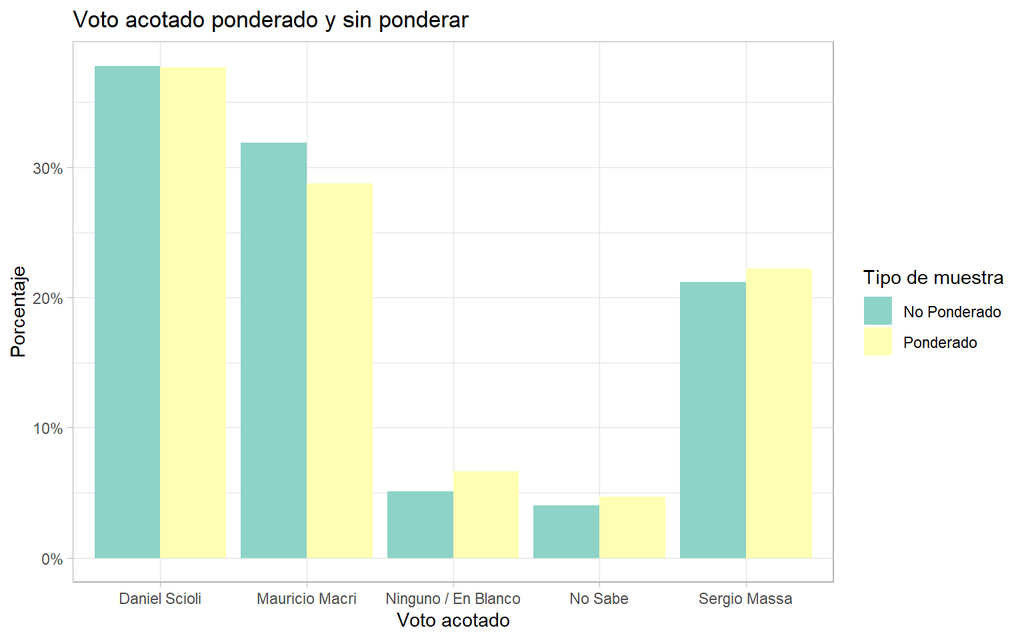

```r
df_gba_summary <- base_baires %>%
  group_by(voto_acotado) %>%
  summarise(n = n_distinct(ua),
            n_pond = sum(ponderacion_eph)) %>%
  mutate(prop_n = (n / sum(n))*100,
         prop_pond = (n_pond / sum(n_pond))*100) %>%
  pivot_longer(cols = c(prop_n, prop_pond), names_to = "Tipo de ponderación", values_to = "Porcentaje") %>%
  mutate(`Tipo de ponderación` = ifelse(`Tipo de ponderación` == "prop_n", "No Ponderado", "Ponderado"))

# Graficamos

ggplot(df_gba_summary, aes(x = voto_acotado, y = Porcentaje, fill = `Tipo de ponderación`)) +
  geom_bar(stat = "identity", position = "dodge") +
  labs(title = "Voto acotado ponderado y sin ponderar",
       x = "Voto acotado",
       y = "Porcentaje",
       fill = "Tipo de muestra") +
  scale_y_continuous(labels = scales::percent_format(scale = 1)) + scale_fill_brewer(palette = "Accent") +
  theme_light() +
    scale_fill_brewer(palette = "Set3")
```

## **Córdoba**

Repetimos el procedimiento con el df de *Córdoba*:

```r
# creo la lista de ponderadores
targets_cordoba <- list(pon_sexo_cordoba,pon_edad_cordoba,pon_educ_cordoba)

# pongo los mismos nombres de las variables del df
names(targets_cordoba) <- c("sexo","edad","ne_cba")

# los ponderadores para iterar
targets_cordoba
```

```
## $sexo
##     Varón     Mujer
## 0.4667904 0.5332096
##
## $edad
##     18-29     30-49     50-65       >65
## 0.2817004 0.3795721 0.2026046 0.1361230
##
## $ne_cba
##         P. Completa Sec. Comp-Terc. Inc Terc/Univ. Completo
##           0.2382054           0.3958940           0.3659006
```

```r
base_cordoba <-  as.data.frame(df_cordoba_sin_NA)

# creo ponderacion_eph con anesrake
weights_cordoba <- anesrake(inputter = targets_cordoba, dataframe = base_cordoba, caseid = base_cordoba$ua, type = "nolim")
```

```
## [1] "Raking converged in 23 iterations"
```

```r
print(paste("la cantidad de iteraciones necesarias para realizar la ponderación de la muestra fue de", weights_cordoba$iterations, "iteraciones"))
```

```
## [1] "la cantidad de iteraciones necesarias para realizar la ponderación de la muestra fue de 23 iteraciones"
```

```r
# unimos
base_cordoba$ponderacion_eph  <- unlist(weights_cordoba[1])
```

Vemos que se necesitaron 23 iteraciones para ponderar nuestra muestra. A continuación se muestra la nueva distribución población en función de la variable `voto_acotado`

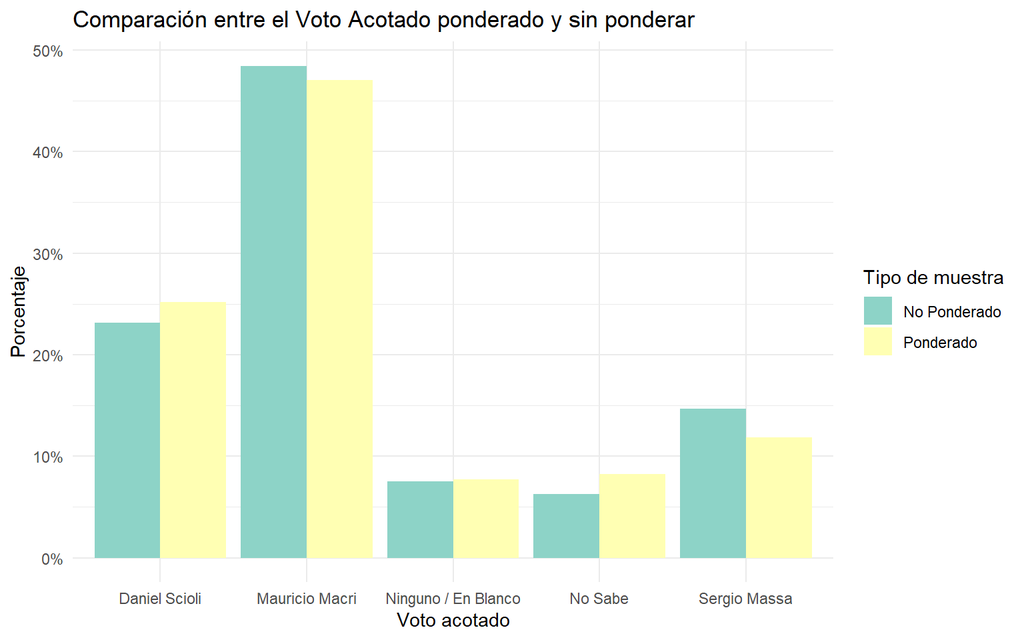

```r
df_cba_summary <- base_cordoba %>%
  group_by(voto_acotado) %>%
  summarise(n = n_distinct(ua),
            n_pond = sum(ponderacion_eph)) %>%
  mutate(prop_n = (n / sum(n))*100,
         prop_pond = (n_pond / sum(n_pond))*100) %>%
  pivot_longer(cols = c(prop_n, prop_pond), names_to = "Tipo de ponderación", values_to = "Porcentaje") %>%
  mutate(`Tipo de ponderación` = ifelse(`Tipo de ponderación` == "prop_n", "No Ponderado", "Ponderado"))

# Graficamos
ggplot(df_cba_summary, aes(x = voto_acotado, y = Porcentaje, fill = `Tipo de ponderación`)) +
  geom_bar(stat = "identity", position = "dodge") +
  labs(title = "Comparación entre el Voto Acotado ponderado y sin ponderar",
       x = "Voto acotado",
       y = "Porcentaje",
       fill = "Tipo de muestra") +
  scale_y_continuous(labels = scales::percent_format(scale = 1)) +
  theme_minimal() +
    scale_fill_brewer(palette = "Set3")
```

# Potencial Electoral

En este apartado se buscará evaluar el potencial electoral de los principales candidatos a Presidente (Macri y Scioli) mediante la técnica de **pisos** y **techos**.

## Cálculo del voto Potencial

Se entiende por **voto potencial** a la estimación del porcentaje máximo de votos que un candidato podría obtener en una elección. Para calcular el voto potencial, se consideran tres grupos de votantes:

- **Votantes Seguros**: Son aquellos que ya han manifestado su intención de votar por un candidato específico y no cambiarán su elección. Para calcular esto se utilizarán las variables `voto_acotado` y `voto_cantidato`
- **Votantes Indecisos**: Son aquellos que aún no han decidido por quién votar y están considerando diferentes opciones.
- **Votantes que No Votarían**: Son aquellos que han manifestado que no votarían por un candidato específico bajo ninguna circunstancia. Para ello, se utilizará la variable `jamas_votaría`

El voto potencial se calcula restando el porcentaje de votantes que no votarían del 100% y luego restando el porcentaje de votantes seguros. Es decir:

| **Voto Potencial = 100% - Porcentaje de Votantes No Votarían - Porcentaje de Votantes Seguros** |
| --- |

El resultado es el porcentaje máximo de votos que un candidato podría obtener si lograra atraer a todos los votantes indecisos. .

### **Buenos Aires**

En primer lugar, se crea la variable `voto_final` imputando los valores de `voto_acotado` para aquellos casos en donde el encuestado *No sabe*

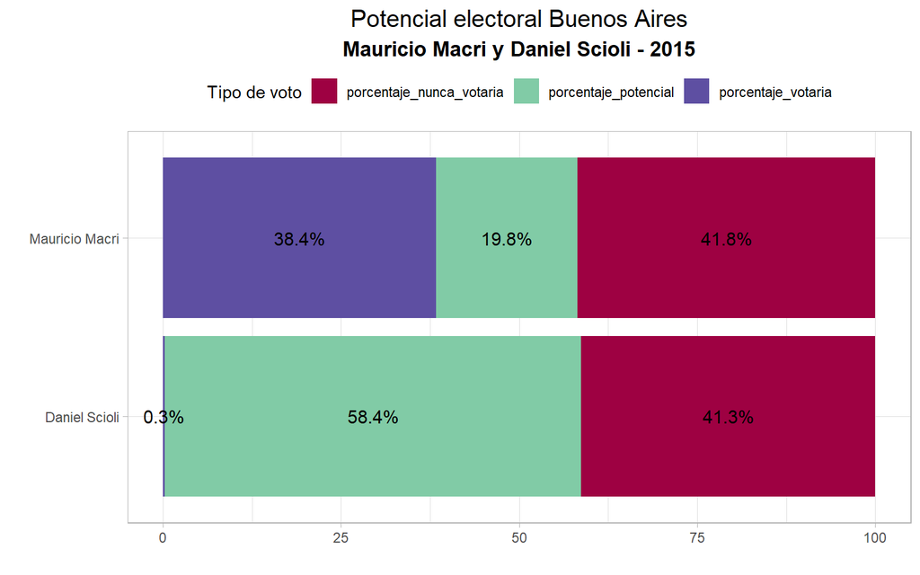

```r
#unique(base_baires$voto_candidato)
df_potencial_ba <- base_baires |>
  mutate(voto_final = ifelse(voto_candidato == "No Sabe", voto_acotado, voto_candidato),
         voto_final = case_when(
           voto_final == 1 ~ "Daniel Scioli",
           voto_final == 2 ~ "Mauricio Macri",
           voto_final == 3 ~ "Sergio Massa",
           voto_final == 4 ~ "Margarita Stolbizer",
           voto_final == 5 ~ "Nicolas Del Caño",
           voto_final == 6 ~ "Adolfo Rodriguez Saa",
           voto_final == 8 ~ "Ninguno / En Blanco",
           voto_final == 9 ~ "No Sabe"))

# Calculamos la intención de voto

#piso
df_baires_intencion <- df_potencial_ba %>%
  group_by(voto_final) %>%
  summarise(tot = sum(ponderacion_eph)) |>
  mutate(porcentaje_votaria = (tot/sum(df_potencial_ba$ponderacion_eph))*100) %>%
  arrange(desc(porcentaje_votaria)) |>
  rename("candidato" = voto_final) |>
  select(-tot)


#techo
df_baires_techo <- df_potencial_ba %>%
  group_by(jamas_votaria) %>%
  summarise(tot = sum(ponderacion_eph)) |>
  mutate(porcentaje_nunca_votaria = (tot/sum(df_potencial_ba$ponderacion_eph))*100) |>
  rename("candidato" = jamas_votaria)|>
  select(-tot)


#unimos
df_pe_gba <- left_join(df_baires_techo, df_baires_intencion, by = "candidato")

#potencial

df_pe_gba <-df_pe_gba |>
  mutate(porcentaje_potencial = 100-(porcentaje_votaria+porcentaje_nunca_votaria))

# Filtramos por los candidatos solicitados
df_pe_gba <- df_pe_gba %>%
  filter(candidato %in% c("Daniel Scioli", "Mauricio Macri"))

# Seleccionar columnas relevantes para el gráfico
cols <- c("porcentaje_votaria", "porcentaje_potencial", "porcentaje_nunca_votaria")

# Graficamos
df_pe_gba |>
  pivot_longer(cols, names_to = "tipo_voto",values_to = "prop") |> ggplot() +
 aes(x = candidato, y = prop, fill = tipo_voto,label = paste0(round(prop, 1), "%")) +
 geom_col() +
 scale_fill_manual(values = c(porcentaje_nunca_votaria = "#9E0142",
porcentaje_potencial = "#81CBA6", porcentaje_votaria = "#5E4FA2")) +
 labs(x = " ", y = " ", title = "Potencial electoral Buenos Aires",
 subtitle = "Mauricio Macri y Daniel Scioli - 2015", fill = "Tipo de voto") +
 coord_flip() +
 theme_light() +
 theme(legend.position = "top", plot.title = element_text(size = 15L, hjust = 0.5), plot.subtitle = element_text(size = 13L,
 face = "bold", hjust = 0.5)) +
  geom_text(position = position_stack(vjust = 0.5), size = 4, color = "black")
```

### **Córdoba**

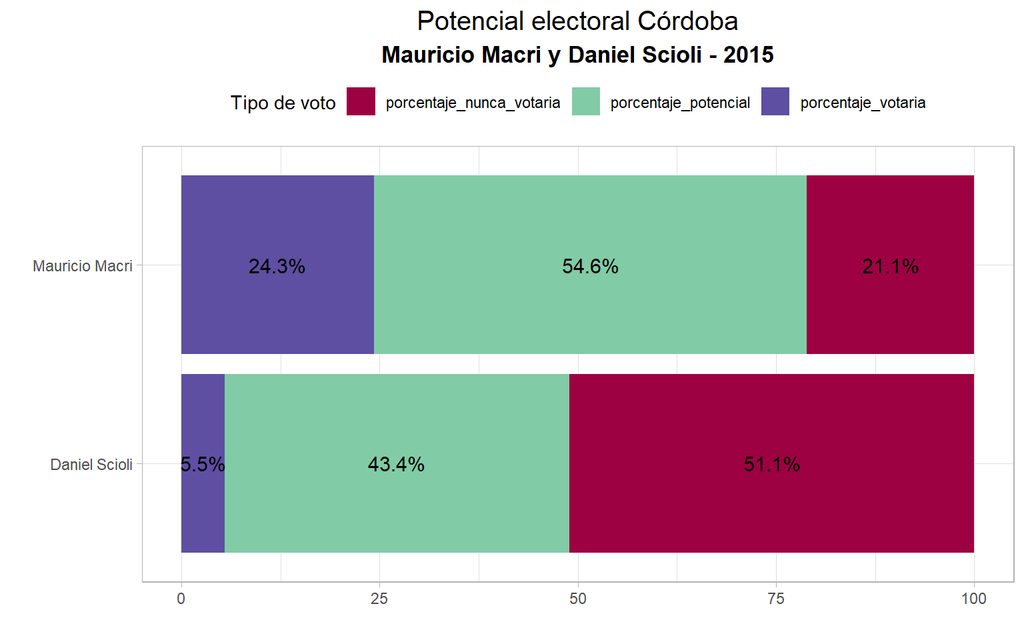

```r
#unique(base_baires$voto_candidato)
df_potencial_cba <- base_cordoba |>
  mutate(voto_final = ifelse(voto_candidato == "No Sabe", voto_acotado, voto_candidato),
         voto_final = case_when(
           voto_final == 1 ~ "Daniel Scioli",
           voto_final == 2 ~ "Mauricio Macri",
           voto_final == 3 ~ "Sergio Massa",
           voto_final == 4 ~ "Margarita Stolbizer",
           voto_final == 5 ~ "Nicolas Del Caño",
           voto_final == 6 ~ "Adolfo Rodriguez Saa",
           voto_final == 8 ~ "Ninguno / En Blanco",
           voto_final == 9 ~ "No Sabe"))

# Calculamos la intención de voto

#piso
df_cordoba_intencion <- df_potencial_cba %>%
  group_by(voto_final) %>%
  summarise(tot = sum(ponderacion_eph)) |>
  mutate(porcentaje_votaria = (tot/sum(df_potencial_cba$ponderacion_eph))*100) %>%
  arrange(desc(porcentaje_votaria)) |>
  rename("candidato" = voto_final) |>
  select(-tot)


#techo
df_cordoba_techo <- df_potencial_cba %>%
  group_by(jamas_votaria) %>%
  summarise(tot = sum(ponderacion_eph)) |>
  mutate(porcentaje_nunca_votaria = (tot/sum(df_potencial_ba$ponderacion_eph))*100) |>
  rename("candidato" = jamas_votaria)|>
  select(-tot)


#unimos
df_pe_cba <- left_join(df_cordoba_techo, df_cordoba_intencion, by = "candidato")

#potencial

df_pe_cba <-df_pe_cba |>
  mutate(porcentaje_potencial = 100-(porcentaje_votaria+porcentaje_nunca_votaria))

# Filtramos por los candidatos solicitados
df_pe_cba <- df_pe_cba %>%
  filter(candidato %in% c("Daniel Scioli", "Mauricio Macri"))

# Seleccionar columnas relevantes para el gráfico
cols <- c("porcentaje_votaria", "porcentaje_potencial", "porcentaje_nunca_votaria")

# Graficamos
df_pe_cba |>
  pivot_longer(cols, names_to = "tipo_voto",values_to = "prop") |> ggplot() +
 aes(x = candidato, y = prop, fill = tipo_voto,label = paste0(round(prop, 1), "%")) +
 geom_col() +
 scale_fill_manual(values = c(porcentaje_nunca_votaria = "#9E0142",
porcentaje_potencial = "#81CBA6", porcentaje_votaria = "#5E4FA2")) +
 labs(x = " ", y = " ", title = "Potencial electoral Córdoba",
 subtitle = "Mauricio Macri y Daniel Scioli - 2015", fill = "Tipo de voto") +
 coord_flip() +
 theme_light() +
 theme(legend.position = "top", plot.title = element_text(size = 15L, hjust = 0.5), plot.subtitle = element_text(size = 13L,
 face = "bold", hjust = 0.5)) +
  geom_text(position = position_stack(vjust = 0.5), size = 4, color = "black")
```

## Potencial Electoral Cruzado

A continuación se realiza otra forma de analizar el potencial electoral y es teniendo en cuenta los votos “*en disputa”*

- **Votaría al candidato**: Representa el porcentaje de personas que tienen la intención de votar por el candidato en cuestión.
- **En disputa**: Representa el porcentaje de personas que todavía no han decidido su voto (indecisos)
- **Jamás votaría al candidato**: Representa el porcentaje de personas que han manifestado que nunca votarían por el candidato.

En este punto lo que se realiza es en los casos en donde no se vota a ninguno de los candidatos principales en `voto_final` se imputa el valor “indeciso” y, para los casos en donde en `jamás_votaría` se eligieron candidatos que no son ni *Mauricio Macri* y *Daniel Scioli* se imputa el valor “indeciso”

### **Buenos Aires**

```r
df_potencial_ba_cruz <- df_potencial_ba %>%
  filter(! voto_final == "Ninguno / En Blanco") |>
  mutate(voto_final = ifelse(
    !(voto_final == "Daniel Scioli" & voto_final == "Mauricio Macri"), "Indeciso", voto_final), # indeciso: voto final no es ni MM ni DS
    nunca_final = ifelse(jamas_votaria == "Daniel Scioli" | jamas_votaria == "Mauricio Macri",jamas_votaria, "En disputa"),
    nunca_final = ifelse(nunca_final == 1, "Daniel Scioli",
                         ifelse(nunca_final == 2, "Mauricio Macri",
                                nunca_final)))# En disputa los que no elijen a MM y DS como jamas votaria

# Calculo totales
ba_cruzado <- df_potencial_ba_cruz %>%
  group_by(voto_final, nunca_final) %>%
  summarise(tot = sum(ponderacion_eph)) |>
  mutate(porcentaje_potencial = round(tot/sum(df_potencial_ba$ponderacion_eph)*100,2)) |>
  select(-tot) |>
  pivot_wider(names_from = nunca_final, values_from = porcentaje_potencial)


# mostramos
ba_cruzado  %>%
  kableExtra::kable(caption = "Potencial Electoral Cruzado - Mauricio Macri y Daniel Scioli (2015) - Buenos Aires") %>%
  kableExtra::kable_styling(bootstrap_options = "responsive")
```

Potencial Electoral Cruzado - Mauricio Macri y Daniel Scioli (2015) - Buenos Aires

| voto_final | Daniel Scioli | En disputa | Mauricio Macri |
| --- | --- | --- | --- |
| Indeciso | 29.71 | 14.51 | 35.54 |

### **Córdoba**

```r
df_potencial_cba_cruz <- df_potencial_cba %>%
  filter(! voto_final == "Ninguno / En Blanco") |>
  mutate(voto_final = ifelse(
    voto_final != "Daniel Scioli" & voto_final != "Mauricio Macri", "Indeciso", voto_final), # indeciso: voto final no es ni MM ni DS
    nunca_final = ifelse(jamas_votaria == "Daniel Scioli" | jamas_votaria == "Mauricio Macri",jamas_votaria, "En disputa"),
    nunca_final = ifelse(nunca_final == 1, "Daniel Scioli",
                         ifelse(nunca_final == 2, "Mauricio Macri",
                                nunca_final)))# En disputa los que no elijen a MM y DS como jamas votaria

# Calculo totales
cba_cruzado <- df_potencial_cba_cruz %>%
  group_by(voto_final, nunca_final) %>%
  summarise(tot = sum(ponderacion_eph)) |>
  mutate(porcentaje_potencial = round(tot/sum(df_potencial_ba$ponderacion_eph)*100,2)) |>
  select(-tot) |>
  pivot_wider(names_from = nunca_final, values_from = porcentaje_potencial)


# mostramos

cba_cruzado  %>%
  kableExtra::kable(caption = "Potencial Electoral Cruzado - Mauricio Macri y Daniel Scioli (2015) - Córdoba") %>%
  kableExtra::kable_styling(bootstrap_options = "responsive")
```

Potencial Electoral Cruzado - Mauricio Macri y Daniel Scioli (2015) - Córdoba

| voto_final | Daniel Scioli | En disputa | Mauricio Macri |
| --- | --- | --- | --- |
| Daniel Scioli | 0.91 | 2.88 | 0.90 |
| Indeciso | 40.24 | 8.54 | 1.40 |
| Mauricio Macri | 1.28 | 1.77 | 17.79 |

# Comportamiento electoral

En este apartado se buscará seleccionar un conjunto de indicadores que den cuenta de dos de las perspectivas teóricas vistas en la bibliografía sobre comportamiento electoral y evaluar el impacto de dichos indicadores en la decisión de voto utilizando al menos dos herramientas de análisis comparando los resultados entre ambas ciudades

Existen tres modelos dentro de la teoría del comportamiento electoral: El modelo sociológico, el modelo psico-social y, el modelo racional-económico. Para el desarrollo de este apartado se seleccionó el **modelo racional** y, el **modelo sociológico**

## Modelo Racional

El **Modelo Racional** de comportamiento electoral se basa en la idea de que los votantes *toman decisiones electorales de manera racional y maximizan sus intereses personales y preferencias al elegir a qué candidato o partido votar*. Este enfoque se deriva de la teoría económica y se centra en la idea de que los individuos actúan como “homo economicus”, es decir, como seres racionales y egoístas que buscan maximizar su bienestar personal. En el contexto electoral, el modelo racional asume que los votantes evalúan cuidadosamente las opciones políticas disponibles y toman decisiones en función de cómo creen que cada candidato o partido cumplirá con sus preferencias y necesidades. En este modelo, **el electorado responsabiliza a los actores políticos del Estado de la economía y votan en función de la evaluación que realizan al respecto**

En este marco, se realizará una clusterización con kmeans de la muestra para analizar la relación de las variables económicas en el voto al **Frente para la Victoria (FPV)**. Se elige este partido con el objetivo de evaluar si, en función de las variables económicas y de gestión, el electorado elige continuar con el gobierno oficialista o prefiere cambiar, y qué variables influyen en dicha decisión. Para dicho análisis se utilizarán las variables `gestion_cristina`, `economia_pais_2_anos`, `economia_fliar_2_anos`, `continuidad_o_cambio`, `voto_acotado` y `ponderacion_eph`

### **Buenos Aires**

En primer lugar, se crea un df con las variables que podrían explicar el voto al Frente para la Victoria en función del modelo relacional. Se construirá una variable binaria que sea ¿Vota al Frente para la Victoria (FPV)? “Sí, No” a partir de la variable `voto_acotado`

```r
# Observamos las variables y su relación
comp_elect_bsas <- df_potencial_ba |>
  mutate(voto_oficialista = ifelse(voto_acotado == "Daniel Scioli" , "Si", "No")) |>
  select(gestion_cristina, economia_fliar_2_anos, economia_pais_2_anos, continuidad_o_cambio,voto_oficialista, ua, ponderacion_eph, voto_final)
```

Analizamos la relación entre las variables y `voto_oficialista`

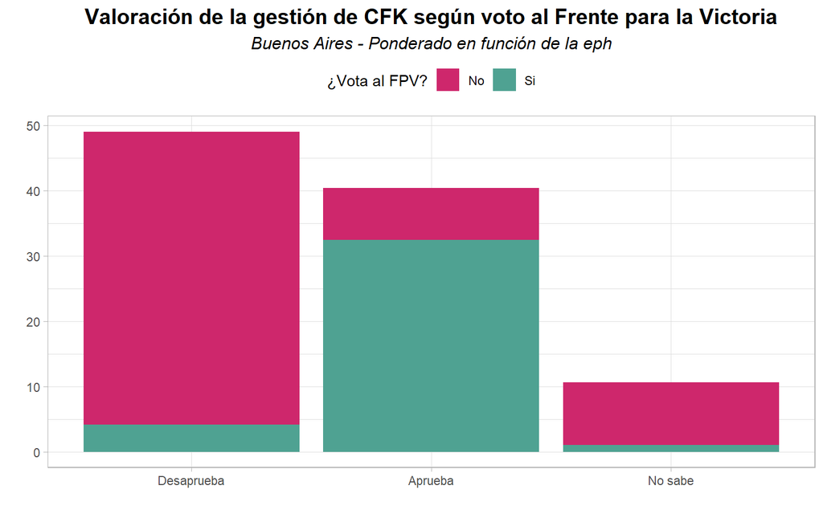

```r
comp_elect_bsas |>
  group_by(voto_oficialista, gestion_cristina) |>
  summarise(total = sum(ponderacion_eph)) |>
  mutate(porcentaje = total/sum(comp_elect_bsas$ponderacion_eph),
         porcentaje = porcentaje*100) |>
  ggplot() +
 aes(x = gestion_cristina, y = porcentaje, fill = voto_oficialista) +
 geom_col() +
 scale_fill_manual(values = c(No = "#CE276C", Si = "#4FA292")) +
 labs(x = " ", y = " ", title = "Valoración de la gestión de CFK según voto al Frente para la Victoria",
 subtitle = "Buenos Aires - Ponderado en función de la eph", fill = "¿Vota al FPV?") +
 theme_light() +
 theme(legend.position = "top",
 plot.title = element_text(size = 15L, face = "bold", hjust = 0.5), plot.subtitle = element_text(size = 12L,
 face = "italic", hjust = 0.5))
```

Se observa que quienes votan al FPV en `voto_acotado`, el 32% aprueba la gestión de cristina 2007-2015. Y, el 44,8% que no aprueba el desempeño en la gestión no votará al FPV

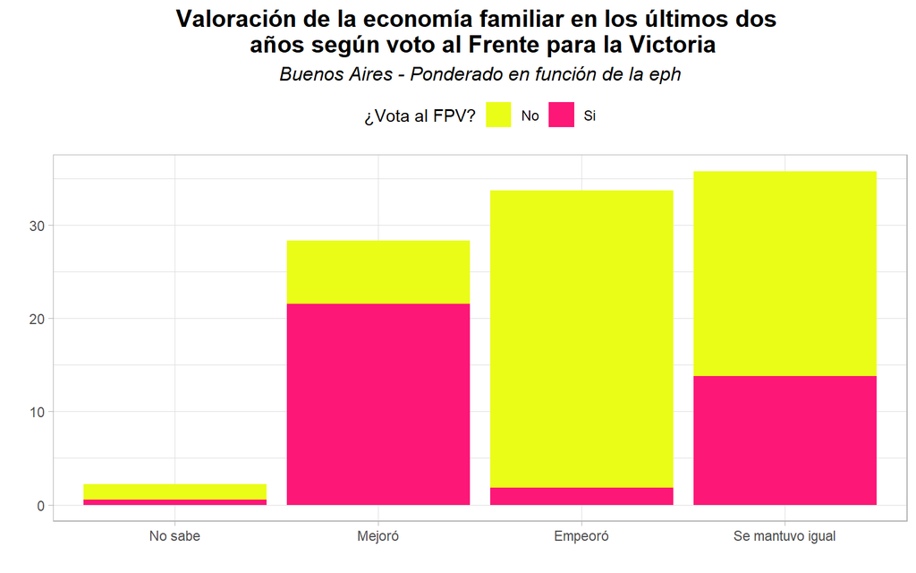

```r
comp_elect_bsas |>
  group_by(voto_oficialista, economia_fliar_2_anos) |>
  summarise(total = sum(ponderacion_eph)) |>
  mutate(porcentaje = total/sum(comp_elect_bsas$ponderacion_eph),
         porcentaje = porcentaje*100) |>
  ggplot() +
 aes(x = reorder(economia_fliar_2_anos,porcentaje), y = porcentaje, fill = voto_oficialista) +
 geom_col() +
 scale_fill_manual(values = c(No = "#eafd17", Si = "#fd1777")) +
 labs(x = " ", y = " ", title = "Valoración de la economía familiar en los últimos dos \n años según voto al Frente para la Victoria",
 subtitle = "Buenos Aires - Ponderado en función de la eph", fill = "¿Vota al FPV?") +
 theme_light() +
 theme(legend.position = "top",
 plot.title = element_text(size = 15L, face = "bold", hjust = 0.5), plot.subtitle = element_text(size = 12L,
 face = "italic", hjust = 0.5))
```

En la misma linea, la mayoría de los que considera que empeoró su situación económica familiar no votará al FPV

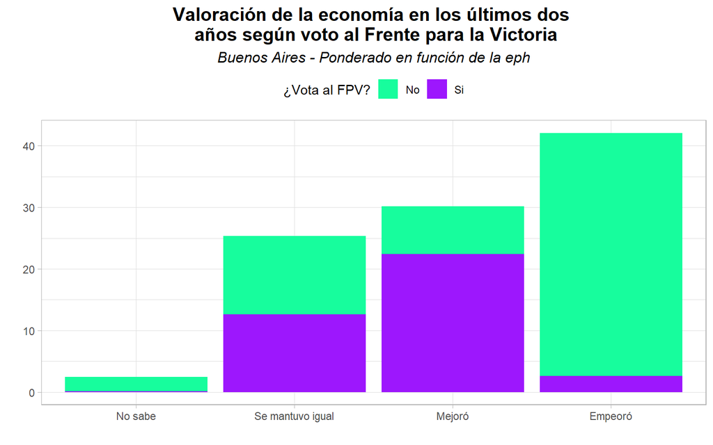

```r
comp_elect_bsas |>
  group_by(voto_oficialista, economia_pais_2_anos) |>
  summarise(total = sum(ponderacion_eph)) |>
  mutate(porcentaje = total/sum(comp_elect_bsas$ponderacion_eph),
         porcentaje = porcentaje*100) |>
  ggplot() +
 aes(x = reorder(economia_pais_2_anos,porcentaje), y = porcentaje, fill = voto_oficialista) +
 geom_col() +
 scale_fill_manual(values = c(No = "#17fd9d", Si = "#9d17fd")) +
 labs(x = " ", y = " ",
      title = "Valoración de la economía en los últimos dos \n años según voto al Frente para la Victoria",
 subtitle = "Buenos Aires - Ponderado en función de la eph", fill = "¿Vota al FPV?") +
 theme_light() +
 theme(legend.position = "top",
 plot.title = element_text(size = 15L, face = "bold", hjust = 0.5), plot.subtitle = element_text(size = 12L,
 face = "italic", hjust = 0.5))
```

En este caso, sucede igual que con la variable anterior, entre quienes votarán al FPV hay valoraciones más positivas de la situación económica de los últimos dos años

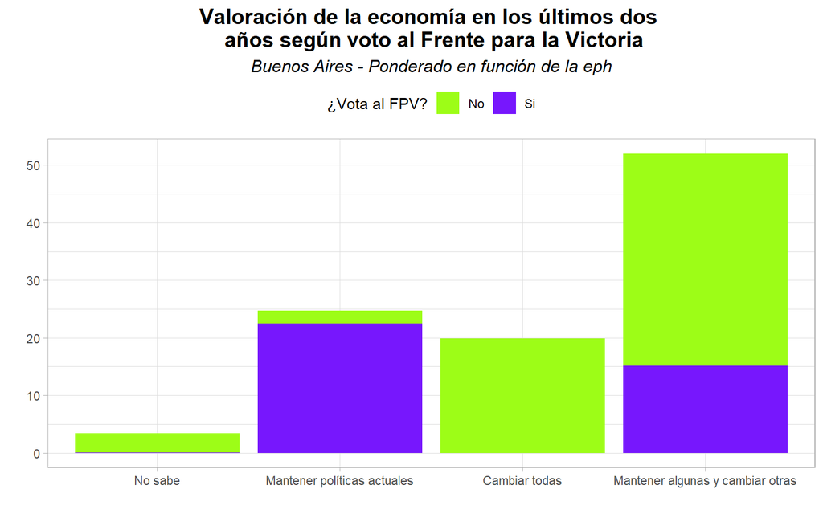

```r
comp_elect_bsas |>
  group_by(voto_oficialista, continuidad_o_cambio) |>
  summarise(total = sum(ponderacion_eph)) |>
  mutate(porcentaje = total/sum(comp_elect_bsas$ponderacion_eph),
         porcentaje = porcentaje*100) |>
  ggplot() +
 aes(x = reorder(continuidad_o_cambio,porcentaje), y = porcentaje, fill = voto_oficialista) +
 geom_col() +
 scale_fill_manual(values = c(No = "#9dfd17", Si = "#7717fd")) +
 labs(x = " ", y = " ",
      title = "Valoración de la economía en los últimos dos \n años según voto al Frente para la Victoria",
 subtitle = "Buenos Aires - Ponderado en función de la eph", fill = "¿Vota al FPV?") +
 theme_light() +
 theme(legend.position = "top",
 plot.title = element_text(size = 15L, face = "bold", hjust = 0.5), plot.subtitle = element_text(size = 12L,
 face = "italic", hjust = 0.5))
```

En este gráfico vemos que los que votarían al FPV consideran que se deben mantener las políticas actuales y mantener algunas y cambiar otras a diferencia de quienes no los votarían

```r
#unique(df_potencial_ba$voto_final)
comp_elect_bsas <- df_potencial_ba |>
  mutate(voto_oficialista = ifelse(voto_acotado == "Daniel Scioli" , 1, 0))

# armo df para crear dummys
df_dummys <- df_potencial_ba |>
  dplyr::select(gestion_cristina, economia_fliar_2_anos, economia_pais_2_anos, continuidad_o_cambio)

#Creo variables dummys
dummy<- data.frame(sapply(df_dummys,function(x) data.frame(model.matrix(~x-1,data =df_dummys))[,-1])) |>
  clean_names()

# uno dfs
comp_elect_bsas <- comp_elect_bsas|>
  dplyr::select(ua, voto_oficialista, ponderacion_eph)|>
   cbind(dummy)
```

Cómo no es posible ponderar desde la propia función de kmeans, se replicarán las filas de la base en función de la ponderación. Además se crearon **variables dummy** con las ya mencionadas para poder realizar el análisis.

```r
df_cluster <- comp_elect_bsas

# replicamos
df_cluster <- df_cluster[rep(seq_len(nrow(df_cluster)), df_cluster$ponderacion_eph), ]

# mostramos
df_cluster |>
  head() |>
  kable()
```

|  | ua | voto_oficialista | ponderacion_eph | gestion_cristina_x_aprueba | gestion_cristina_x_no_sabe | economia_fliar_2_anos_x_empeoro | economia_fliar_2_anos_x_se_mantuvo_igual | economia_fliar_2_anos_x_no_sabe | economia_pais_2_anos_x_empeoro | economia_pais_2_anos_x_se_mantuvo_igual | economia_pais_2_anos_x_no_sabe | continuidad_o_cambio_x_mantener_algunas_y_cambiar_otras | continuidad_o_cambio_x_cambiar_todas | continuidad_o_cambio_x_no_sabe |
| --- | --- | --- | --- | --- | --- | --- | --- | --- | --- | --- | --- | --- | --- | --- |
| 1 | 1 | 1 | 1.537161 | 1 | 0 | 0 | 0 | 0 | 0 | 1 | 0 | 1 | 0 | 0 |
| 4 | 4 | 1 | 1.265581 | 1 | 0 | 0 | 0 | 0 | 0 | 1 | 0 | 0 | 0 | 0 |
| 5 | 5 | 0 | 1.454980 | 0 | 0 | 1 | 0 | 0 | 1 | 0 | 0 | 1 | 0 | 0 |
| 8 | 8 | 1 | 1.265581 | 1 | 0 | 0 | 0 | 0 | 0 | 0 | 0 | 1 | 0 | 0 |
| 9 | 9 | 1 | 1.215594 | 1 | 0 | 0 | 1 | 0 | 0 | 0 | 0 | 1 | 0 | 0 |
| 11 | 11 | 0 | 1.767203 | 1 | 0 | 0 | 0 | 0 | 0 | 0 | 0 | 1 | 0 | 0 |

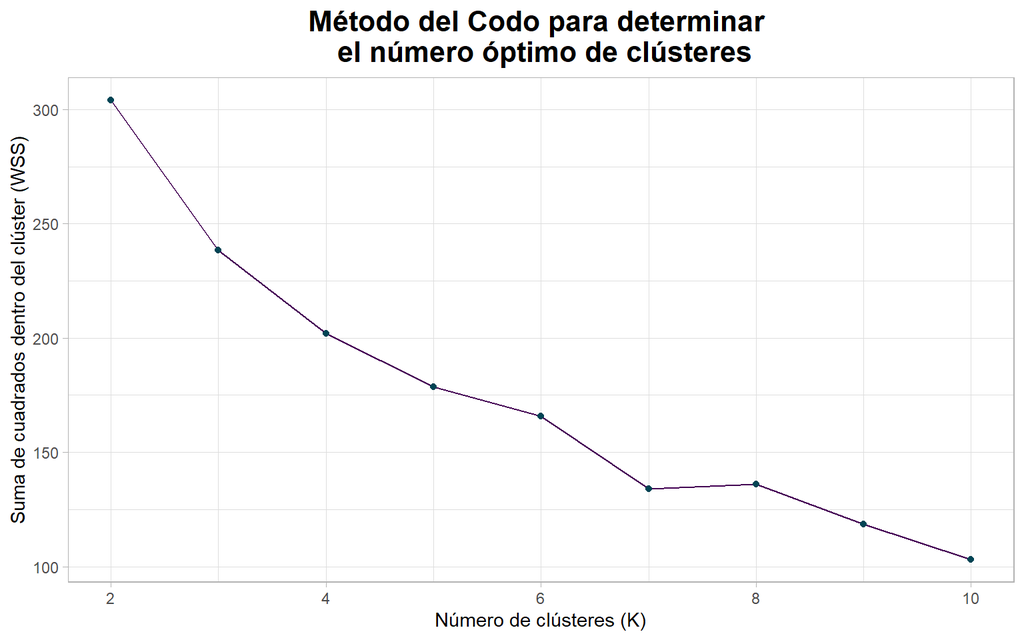

```r
df_cluster <- df_cluster |>
  dplyr::select(-ponderacion_eph, -ua)

# armamos el plot
k_values <- 2:10
wss <- numeric(length(k_values))

for (k in k_values) {
  km <- kmeans(df_cluster,centers = k, nstart = 10)
  wss[k-1] <- sum(km$withinss)
}

# Realizo el método de Elbow para saber cuantos clusters realizar
elbow_plot <- data.frame(K = k_values, WSS = wss) %>%
  ggplot(aes(x = K, y = WSS)) +
  geom_line(colour = "#440154") +
  geom_point(colour = "#014454") +
  labs(x = "Número de clústeres (K)", y = "Suma de cuadrados dentro del clúster (WSS)",
       title = "Método del Codo para determinar \n el número óptimo de clústeres") +
  theme_light() +
  theme(
    plot.title = element_text(size = 16L,
    face = "bold",
    hjust = 0.5),
    plot.subtitle = element_text(face = "italic",
    hjust = 0.5)
  )

elbow_plot
```

Vamos a realizar el análisis con 3 clusters

```r
# semilla
set.seed(123)

# realizamos el cluster
kmeans_result <- kmeans(df_cluster, centers = 3 )

# lo agregamos al dataset
df_cluster$cluster <- kmeans_result$cluster

# resumen
aggregate(. ~ cluster, data = df_cluster, FUN = mean) |>
  kable()
```

| cluster | voto_oficialista | gestion_cristina_x_aprueba | gestion_cristina_x_no_sabe | economia_fliar_2_anos_x_empeoro | economia_fliar_2_anos_x_se_mantuvo_igual | economia_fliar_2_anos_x_no_sabe | economia_pais_2_anos_x_empeoro | economia_pais_2_anos_x_se_mantuvo_igual | economia_pais_2_anos_x_no_sabe | continuidad_o_cambio_x_mantener_algunas_y_cambiar_otras | continuidad_o_cambio_x_cambiar_todas | continuidad_o_cambio_x_no_sabe |
| --- | --- | --- | --- | --- | --- | --- | --- | --- | --- | --- | --- | --- |
| 1 | 0.0327869 | 0.0655738 | 0.2459016 | 0.0327869 | 0.8196721 | 0.0655738 | 0.4262295 | 0.4426230 | 0.0000000 | 0.8688525 | 0.0983607 | 0.0327869 |
| 2 | 0.9204545 | 0.8863636 | 0.0227273 | 0.0568182 | 0.3409091 | 0.0227273 | 0.0568182 | 0.3295455 | 0.0000000 | 0.3977273 | 0.0000000 | 0.0000000 |
| 3 | 0.0000000 | 0.1044776 | 0.1194030 | 0.9104478 | 0.0000000 | 0.0000000 | 0.8059701 | 0.0149254 | 0.0895522 | 0.4029851 | 0.5074627 | 0.0895522 |

*Un segundo cluster* al que denominaremos **Los Leales** con un 92% de intención de votar al Frente para la Victoria. Este grupo se caracteriza por tener una alta proporción de aprobación de la gestión del gobierno de CFK,una baja proporción de `economia_fliar_2_anos_x_empeoro` y `economia_pais_2_anos_x_empeoro` lo que sugiere que no creen que la economía familiar o la del país hayan empeorado en los últimos 2 años. En términos de preferencia por la continuidad o cambio, tienen una baja proporción de `continuidad_o_cambio_x_mantener_algunas_y_cambiar_otras` y `continuidad_o_cambio_x_cambiar_todas`, lo que indica que prefieren mantener las políticas actuales

Y, por último, *Un tercer grupo* de **Los desencantados** que no votará por el FPV con una baja proporción de `gestion_cristina_x_aprueba` y `gestion_cristina_x_no_sabe`, lo que indica que desaprueban la gestión de CFK. Respecto a la percepción económica, tienen una alta proporción de `economia_fliar_2_anos_x_empeoro` y `economia_pais_2_anos_x_empeoro`, lo que sugiere que creen que la economía familiar y la del país empeoró en los últimos años. Respecto a las políticas, tienen una alta proporción de `continuidad_o_cambio_x_cambiar_todas`

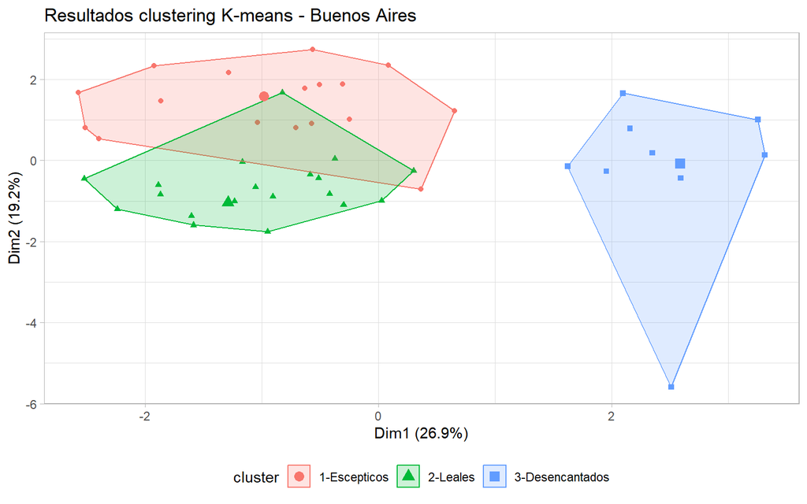

```r
# Le ponemos los nombres a los clusters
cluster_names <- c("1-Escepticos", "2-Leales", "3-Desencantados")

kmeans_result$cluster <- cluster_names[kmeans_result$cluster]

# Visualizamos
fviz_cluster(kmeans_result, data = df_cluster, geom = "point") +
  theme_light() +  theme(legend.position = "bottom") +
  labs(title = "Resultados clustering K-means - Buenos Aires")
```

### **Córdoba**

Se realizará el mismo procedimiento que con el df de **Buenos Aires**. En primer lugar se crea un df con las variables que podrían explicar el voto al **FPV** en función del modelo racional. Se construirá una variable binaria que sea ¿Vota al Frente para la Victoria (FPV)? “Sí, No” a partir de la variable `voto_acotado`

```r
# Observamos las variables y su relación
comp_elect_cba <- df_potencial_cba |>
  mutate(voto_oficialista = ifelse(voto_acotado == "Daniel Scioli" , "Si", "No")) |>
  select(gestion_cristina, economia_fliar_2_anos, economia_pais_2_anos, continuidad_o_cambio,voto_oficialista, ua, ponderacion_eph, voto_final)
```

Analizamos la relación entre las variables y `voto_oficialista`

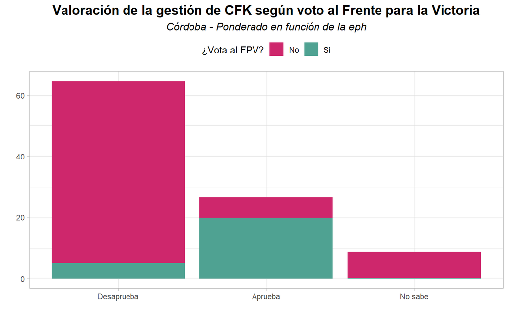

```r
comp_elect_cba |>
  group_by(voto_oficialista, gestion_cristina) |>
  summarise(total = sum(ponderacion_eph)) |>
  mutate(porcentaje = total/sum(comp_elect_cba$ponderacion_eph),
         porcentaje = porcentaje*100) |>
  ggplot() +
 aes(x = gestion_cristina, y = porcentaje, fill = voto_oficialista) +
 geom_col() +
 scale_fill_manual(values = c(No = "#CE276C", Si = "#4FA292")) +
 labs(x = " ", y = " ", title = "Valoración de la gestión de CFK según voto al Frente para la Victoria",
 subtitle = "Córdoba - Ponderado en función de la eph", fill = "¿Vota al FPV?") +
 theme_light() +
 theme(legend.position = "top",
 plot.title = element_text(size = 15L, face = "bold", hjust = 0.5), plot.subtitle = element_text(size = 12L,
 face = "italic", hjust = 0.5))
```

Se observa que quienes votan al FPV en `voto_acotado`, el 19% aprueba la gestión de cristina 2007-2015. Y, el 59% que no aprueba el desempeño en la gestión no votará al FPV

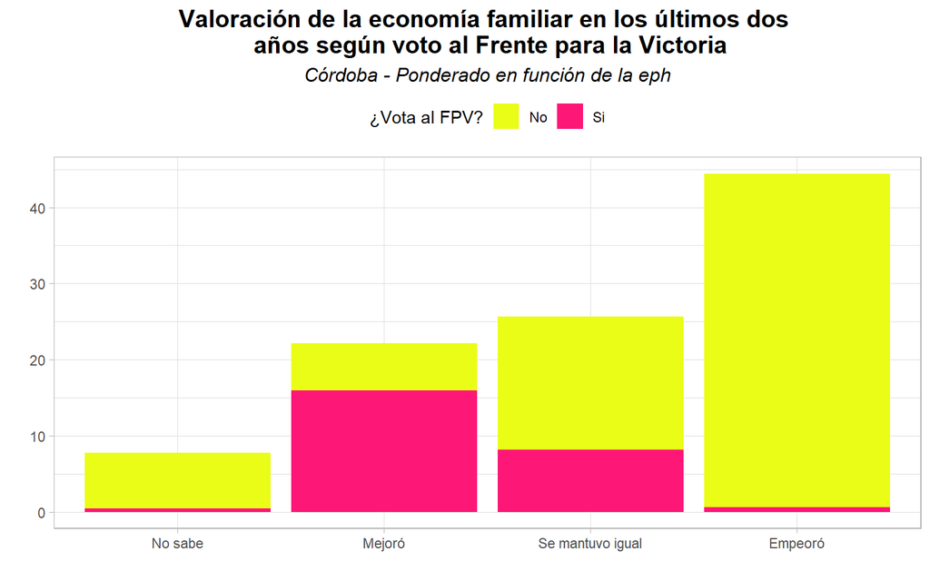

```r
comp_elect_cba |>
  group_by(voto_oficialista, economia_fliar_2_anos) |>
  summarise(total = sum(ponderacion_eph)) |>
  mutate(porcentaje = total/sum(comp_elect_cba$ponderacion_eph),
         porcentaje = porcentaje*100) |>
  ggplot() +
 aes(x = reorder(economia_fliar_2_anos,porcentaje), y = porcentaje, fill = voto_oficialista) +
 geom_col() +
 scale_fill_manual(values = c(No = "#eafd17", Si = "#fd1777")) +
 labs(x = " ", y = " ", title = "Valoración de la economía familiar en los últimos dos \n años según voto al Frente para la Victoria",
 subtitle = "Córdoba - Ponderado en función de la eph", fill = "¿Vota al FPV?") +
 theme_light() +
 theme(legend.position = "top",
 plot.title = element_text(size = 15L, face = "bold", hjust = 0.5), plot.subtitle = element_text(size = 12L,
 face = "italic", hjust = 0.5))
```

En este item, hay una alta proporción que considera que su situación económica familiar empeoró 43% y no votará al oficialismo

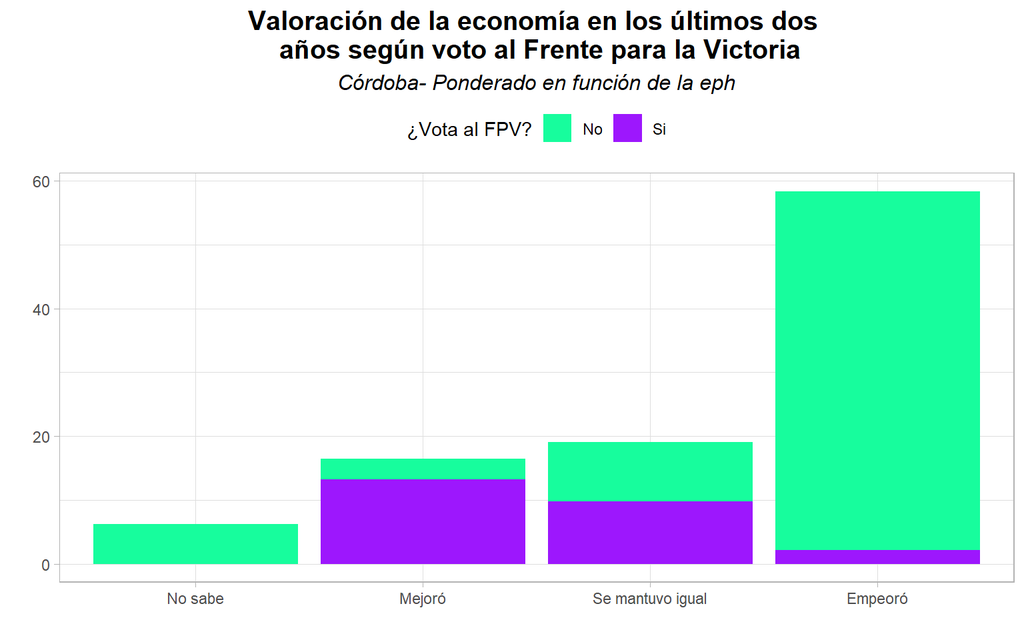

```r
comp_elect_cba |>
  group_by(voto_oficialista, economia_pais_2_anos) |>
  summarise(total = sum(ponderacion_eph)) |>
  mutate(porcentaje = total/sum(comp_elect_cba$ponderacion_eph),
         porcentaje = porcentaje*100) |>
  ggplot() +
 aes(x = reorder(economia_pais_2_anos,porcentaje), y = porcentaje, fill = voto_oficialista) +
 geom_col() +
 scale_fill_manual(values = c(No = "#17fd9d", Si = "#9d17fd")) +
 labs(x = " ", y = " ",
      title = "Valoración de la economía en los últimos dos \n años según voto al Frente para la Victoria",
 subtitle = "Córdoba- Ponderado en función de la eph", fill = "¿Vota al FPV?") +
 theme_light() +
 theme(legend.position = "top",
 plot.title = element_text(size = 15L, face = "bold", hjust = 0.5), plot.subtitle = element_text(size = 12L,
 face = "italic", hjust = 0.5))
```

En este caso sucede igual que con la variable anterior, entre quienes votarán al FPV hay valoraciones más positivas de la situación económica de los últimos dos años

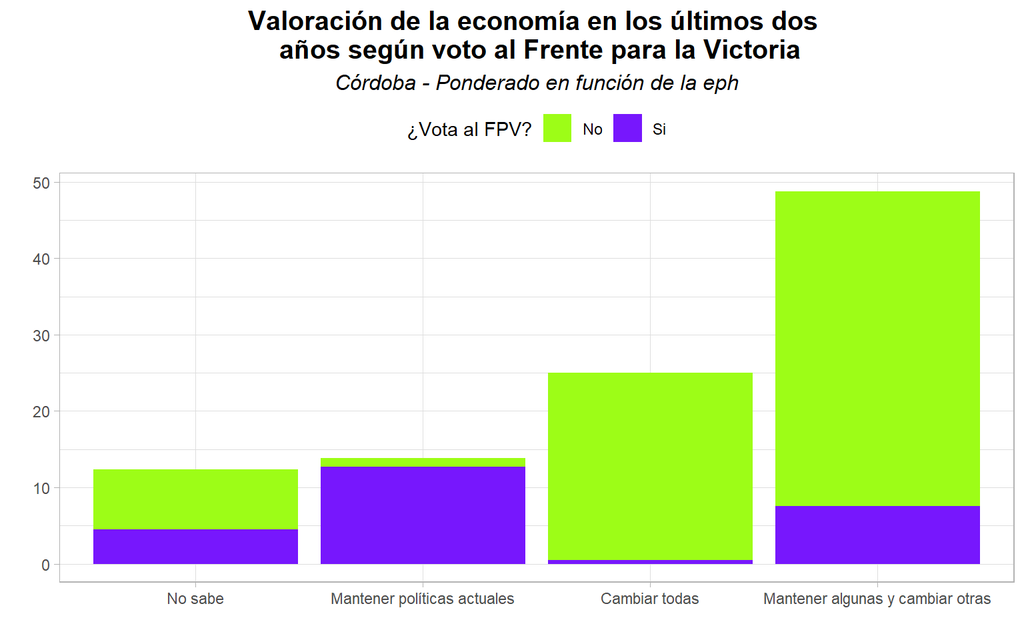

```r
comp_elect_cba |>
  group_by(voto_oficialista, continuidad_o_cambio) |>
  summarise(total = sum(ponderacion_eph)) |>
  mutate(porcentaje = total/sum(comp_elect_cba$ponderacion_eph),
         porcentaje = porcentaje*100) |>
  ggplot() +
 aes(x = reorder(continuidad_o_cambio,porcentaje), y = porcentaje, fill = voto_oficialista) +
 geom_col() +
 scale_fill_manual(values = c(No = "#9dfd17", Si = "#7717fd")) +
 labs(x = " ", y = " ",
      title = "Valoración de la economía en los últimos dos \n años según voto al Frente para la Victoria",
 subtitle = "Córdoba - Ponderado en función de la eph", fill = "¿Vota al FPV?") +
 theme_light() +
 theme(legend.position = "top",
 plot.title = element_text(size = 15L, face = "bold", hjust = 0.5), plot.subtitle = element_text(size = 12L,
 face = "italic", hjust = 0.5))
```

En este gráfico vemos que si bien hay un alto porcentaje entre los que no votarían al FPV que desea cambiar las políticas (24%) la mayoría prediere mantener algunas y cambiar otras.

```r
#unique(df_potencial_ba$voto_final)
comp_elect_cba <- df_potencial_cba |>
  mutate(voto_oficialista = ifelse(voto_acotado == "Daniel Scioli" , 1, 0))

# armo df para crear dummys
df_dummys <- comp_elect_cba |>
  dplyr::select(gestion_cristina, economia_fliar_2_anos, economia_pais_2_anos, continuidad_o_cambio)

#Creo las variables dummys
dummy<- data.frame(sapply(df_dummys,function(x) data.frame(model.matrix(~x-1,data =df_dummys))[,-1])) |>
  clean_names()

# uno dfs
comp_elect_cba <- comp_elect_cba|>
  dplyr::select(ua, voto_oficialista, ponderacion_eph)|>
   cbind(dummy)
```